# videogamessaleanalysis

Ashish Das

10/11/2021

## R Markdown

```r
library(ggplot2)
library(dplyr)
df <- read.csv("E:\\sem5\\cse3505\\Project\\vgsales.csv")
head(df)
```

```
##   Rank                     Name Platform Year        Genre Publisher NA_Sales
## 1    1               Wii Sports      Wii 2019       Sports  Nintendo    41.49
## 2    2        Super Mario Bros.      NES 2018     Platform  Nintendo    29.08
## 3    3           Mario Kart Wii      Wii 2019       Racing  Nintendo    15.85
## 4    4        Wii Sports Resort      Wii 2019       Sports  Nintendo    15.75
## 5    5 Pokemon Red/Pokemon Blue       GB 2018 Role-Playing  Nintendo    11.27
## 6    6                   Tetris       GB 2018       Puzzle  Nintendo    23.20
##   EU_Sales JP_Sales Other_Sales Global_Sales
## 1    29.02     3.77        8.46        82.74
## 2     3.58     6.81        0.77        40.24
## 3    12.88     3.79        3.31        35.82
## 4    11.01     3.28        2.96        33.00
## 5     8.89    10.22        1.00        31.37
## 6     2.26     4.22        0.58        30.26
```

```r
df_clean <- na.omit(df)

sum(is.na(df_clean))
```

```
## [1] 0
```

```r
sum(is.na(df$Rank))
```

```
## [1] 0
```

```r
sum(is.na(df$Name))
```

```
## [1] 0
```

```r
sum(is.na(df$Platform))
```

```
## [1] 0
```

```r
sum(is.na(df$Year))
```

```
## [1] 0
```

```r
sum(is.na(df$Genre))
```

```
## [1] 0
```

```r
sum(is.na(df$Publisher))
```

```
## [1] 0
```

```r
sum(is.na(df$NA_Sales))
```

```
## [1] 0
```

```r
sum(is.na(df$EU_Sales))
```

```
## [1] 0
```

```r
sum(is.na(df$JP_Sales))
```

```
## [1] 0
```

```r
sum(is.na(df$Other_Sales))
```

```
## [1] 0
```

```r
sum(is.na(df$Global_Sales))
```

```
## [1] 0
```

```r
unique(df$NA_Sales)
```

[output not shown]

[output cut: 20 more lines]

# 1. Which region has performed the best in terms of sales?

### We will utilize the average sales made per region and compare the results. Before we do that, let’s make sure we know how to calculate the average. We observe that our output is coming in decimals, to convert the values in millions, let’s multiple the result with 10,00,000. The final code should look like this.

```r
x <- mean(df$NA_Sales,na.rm = TRUE)*1000000
y <- mean(df$EU_Sales,na.rm = TRUE)*1000000
z <- mean(df$JP_Sales,na.rm = TRUE)*1000000
q <- mean(df$Other_Sales,na.rm = TRUE)*1000000
p <- mean(df$Global_Sales,na.rm = TRUE)*1000000
```

```r
print(paste("The average sales in North America =", x))
```

```
## [1] "The average sales in North America = 264667.429810821"
```

```r
print(paste("The average sales in Europe =", y))
```

```
## [1] "The average sales in Europe = 146652.006265815"
```

```r
print(paste("The average sales in Japan =", z))
```

```
## [1] "The average sales in Japan = 77781.660441017"
```

```r
print(paste("The average sales in other regions =", q))
```

```
## [1] "The average sales in other regions = 48063.0196409206"
```

```r
print(paste("The average sales globally =", p))
```

```
## [1] "The average sales globally = 537440.655500663"
```

```r
X <- c(537440.656,264667.430, 146652.006, 77781.660, 48063.020)
Y <- c('Global','North America', 'Europe', 'Japan', 'Other')
```

# Let us now plot our findings on a bar chart.

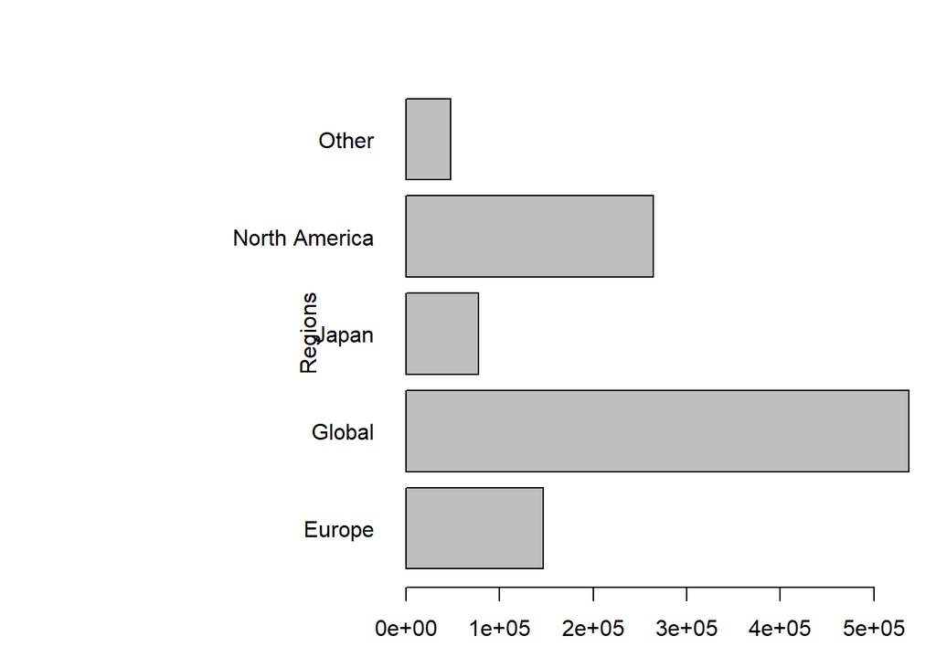

```r
par(mar=c(3, 15, 3, 1))
barplot(X ~ Y,las=1, ylab = "Regions", horiz = TRUE)
```

```r
unique(df$Platform)
```

```
##  [1] "Wii"  "NES"  "GB"   "DS"   "X360" "PS3"  "PS2"  "SNES" "GBA"  "3DS"
## [11] "PS4"  "N64"  "PS"   "XB"   "PC"   "2600" "PSP"  "XOne" "GC"   "WiiU"
## [21] "GEN"  "DC"   "PSV"  "SAT"  "SCD"  "WS"   "NG"   "TG16" "3DO"  "GG"
## [31] "PCFX"
```

#Grouping the Global sales based on each platform

```r
df %>%
  group_by(Platform) %>%
    summarize(Global_Sales)
```

```
## # A tibble: 16,598 x 2
## # Groups:   Platform [31]
##    Platform Global_Sales
##    <chr>           <dbl>
##  1 2600             7.81
##  2 2600             4.5
##  3 2600             4.31
##  4 2600             2.76
##  5 2600             2.53
##  6 2600             2.2
##  7 2600             2.13
##  8 2600             1.97
##  9 2600             1.65
## 10 2600             1.64
## # ... with 16,588 more rows
```

#Grouping the North America sales based on each platform

```r
df %>%
  group_by(Platform) %>%
    summarize(NA_Sales)
```

```
## # A tibble: 16,598 x 2
## # Groups:   Platform [31]
##    Platform NA_Sales
##    <chr>       <dbl>
##  1 2600         7.28
##  2 2600         4.21
##  3 2600         4
##  4 2600         2.56
##  5 2600         2.36
##  6 2600         2.06
##  7 2600         1.99
##  8 2600         1.84
##  9 2600         1.54
## 10 2600         1.52
## # ... with 16,588 more rows
```

#Grouping the Europe sales based on each platform

```r
df %>%
  group_by(Platform) %>%
    summarize(EU_Sales)
```

```
## # A tibble: 16,598 x 2
## # Groups:   Platform [31]
##    Platform EU_Sales
##    <chr>       <dbl>
##  1 2600         0.45
##  2 2600         0.24
##  3 2600         0.26
##  4 2600         0.17
##  5 2600         0.14
##  6 2600         0.12
##  7 2600         0.12
##  8 2600         0.11
##  9 2600         0.1
## 10 2600         0.1
## # ... with 16,588 more rows
```

#Grouping the Japan sales based on each platform

```r
df %>%
  group_by(Platform) %>%
    summarize(JP_Sales)
```

```
## # A tibble: 16,598 x 2
## # Groups:   Platform [31]
##    Platform JP_Sales
##    <chr>       <dbl>
##  1 2600            0
##  2 2600            0
##  3 2600            0
##  4 2600            0
##  5 2600            0
##  6 2600            0
##  7 2600            0
##  8 2600            0
##  9 2600            0
## 10 2600            0
## # ... with 16,588 more rows
```

#Grouping the other countries sales based on each platform

```r
df %>%
  group_by(Platform) %>%
    summarize(Other_Sales)
```

```
## # A tibble: 16,598 x 2
## # Groups:   Platform [31]
##    Platform Other_Sales
##    <chr>          <dbl>
##  1 2600            0.08
##  2 2600            0.05
##  3 2600            0.05
##  4 2600            0.03
##  5 2600            0.03
##  6 2600            0.02
##  7 2600            0.02
##  8 2600            0.02
##  9 2600            0.02
## 10 2600            0.02
## # ... with 16,588 more rows
```

# 3. What are the top 10 games currently making the most sales globally?

# We will use a similar approach by grouping the games with respect to the global sales and observe the top 10 games.

```r
df2 = subset(df, select=c(Name,Global_Sales))
head(df2)
```

```
##                       Name Global_Sales
## 1               Wii Sports        82.74
## 2        Super Mario Bros.        40.24
## 3           Mario Kart Wii        35.82
## 4        Wii Sports Resort        33.00
## 5 Pokemon Red/Pokemon Blue        31.37
## 6                   Tetris        30.26
```

```r
df3<-head(df2,10)
df3<-df3 %>%
  group_by(Name)%>%
  arrange(desc(Global_Sales))
```

## We see the most played game is Wii Sports making a total of $82.74 million globally.

## We will plot the above using a pie chart.

```r
df3
```

```
## # A tibble: 10 x 2
## # Groups:   Name [10]
##    Name                      Global_Sales
##    <chr>                            <dbl>
##  1 Wii Sports                        82.7
##  2 Super Mario Bros.                 40.2
##  3 Mario Kart Wii                    35.8
##  4 Wii Sports Resort                 33
##  5 Pokemon Red/Pokemon Blue          31.4
##  6 Tetris                            30.3
##  7 New Super Mario Bros.             30.0
##  8 Wii Play                          29.0
##  9 New Super Mario Bros. Wii         28.6
## 10 Duck Hunt                         28.3
```

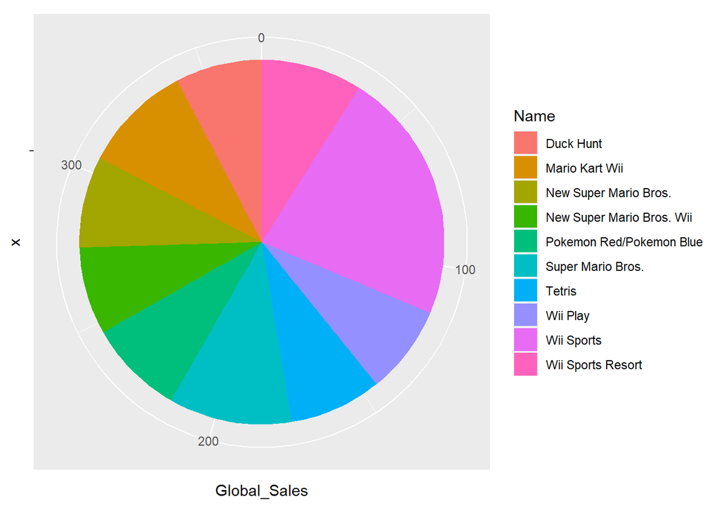

```r
ggplot(df3, aes(x="",y=Global_Sales,fill=Name))+geom_bar(width=1,stat='identity')+coord_polar("y",start = 0)
```

## The pie chart also shows the proportion of sales each game holds, while also depicting the results.

# 4. What are the top games for different regions?

## We will have to compare the sales made by different games regionally. We will use the same approach we did while analyzing the platform.

```r
df4 = subset(df, select=c(Name,NA_Sales))
df4<-head(df4,5)
df4<-df4 %>%
  group_by(Name)%>%
  arrange(desc(NA_Sales))
df4
```

```
## # A tibble: 5 x 2
## # Groups:   Name [5]
##   Name                     NA_Sales
##   <chr>                       <dbl>
## 1 Wii Sports                   41.5
## 2 Super Mario Bros.            29.1
## 3 Mario Kart Wii               15.8
## 4 Wii Sports Resort            15.8
## 5 Pokemon Red/Pokemon Blue     11.3
```

## Plotting it in a similar fashion to understand the results obtained.

[figure not shown]

```r
ggplot(data=df4,mapping=aes(x=Name, fill=NA_Sales))+geom_bar() + ggtitle("Female Left Handers and Male Left Handers")
```

```r
df4 = subset(df, select=c(Name,EU_Sales))
df4<-head(df4,5)
df4<-df4 %>%
  group_by(Name)%>%
  arrange(desc(EU_Sales))
df4
```

```
## # A tibble: 5 x 2
## # Groups:   Name [5]
##   Name                     EU_Sales
##   <chr>                       <dbl>
## 1 Wii Sports                  29.0
## 2 Mario Kart Wii              12.9
## 3 Wii Sports Resort           11.0
## 4 Pokemon Red/Pokemon Blue     8.89
## 5 Super Mario Bros.            3.58
```

[figure not shown]

```r
ggplot(data=df4,mapping=aes(x=Name, fill=EU_Sales))+geom_bar() + ggtitle("Female Left Handers and Male Left Handers")
```

```r
df4 = subset(df, select=c(Name,JP_Sales))
df4<-head(df4,5)
df4<-df4 %>%
  group_by(Name)%>%
  arrange(desc(JP_Sales))
df4
```

```
## # A tibble: 5 x 2
## # Groups:   Name [5]
##   Name                     JP_Sales
##   <chr>                       <dbl>
## 1 Pokemon Red/Pokemon Blue    10.2
## 2 Super Mario Bros.            6.81
## 3 Mario Kart Wii               3.79
## 4 Wii Sports                   3.77
## 5 Wii Sports Resort            3.28
```

[figure not shown]

```r
ggplot(data=df4,mapping=aes(x=Name, fill=JP_Sales))+geom_bar() + ggtitle("Female Left Handers and Male Left Handers")
```

```r
df4 = subset(df, select=c(Name,Other_Sales))
df4<-head(df4,5)
df4<-df4 %>%
  group_by(Name)%>%
  arrange(desc(Other_Sales))
df4
```

```
## # A tibble: 5 x 2
## # Groups:   Name [5]
##   Name                     Other_Sales
##   <chr>                          <dbl>
## 1 Wii Sports                      8.46
## 2 Mario Kart Wii                  3.31
## 3 Wii Sports Resort               2.96
## 4 Pokemon Red/Pokemon Blue        1
## 5 Super Mario Bros.               0.77
```

[figure not shown]

```r
ggplot(data=df4,mapping=aes(x=Name, fill=Other_Sales))+geom_bar() + ggtitle("Female Left Handers and Male Left Handers")
```

## The graph shows us the top games preferred by users in different regions and also globally. We observe the following:

## Wii Sports has been the top game in North America, Europe, other regions.

## Pokemon Red/Pokemon Blue is the top game in Japan.